# EDA Results

## Questions

1. Actual value in total for each season start
   - How much money was spent every year in total for players?
   - Is the amount increasing every year? What is the trend?
2. Most transferred league/team
   - Which leagues are the most valued in terms of the value of players?
   - Which team purchased the most players or spent the most?
   - Which team is a farm (selling players)?
3. Value of players
   - What are the top highest-valued players?
   - How much does the estimated value differ from the actual value?
   - Which players were traded the most?
   - What is their total price after trading multiple times?
4. Position
   - Which positions are most valued?
5. Characteristics
   - What influences player value?
   - Age and value?

## 1. Season Spending

### Is the amount increasing every year? What is the trend?

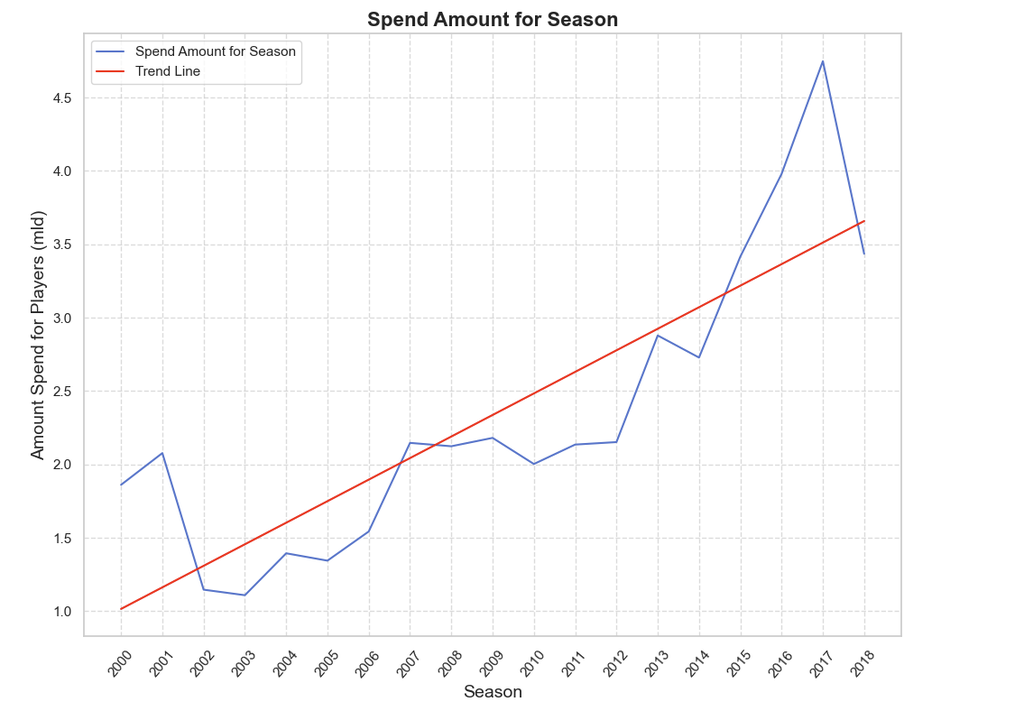

### How much money was spent every year in total for players?

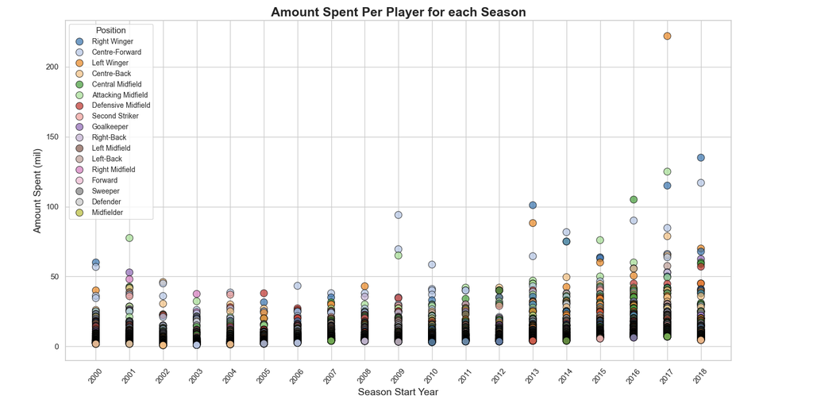

## 2. League/Team value and spending

### Which leagues are the most valued in terms of the value of players?

- The Premier League contains most of the highly valued players (this league contain players with the highest valuation in total).
- All of the leagues are primary main leagues in that particular country:
  - Premier League = UK
  - Serie A = Italy
  - LaLiga = Spain
  - Ligue 1 = France
  - 1Bundesliga = Germany
  - Premier Liga = Russia

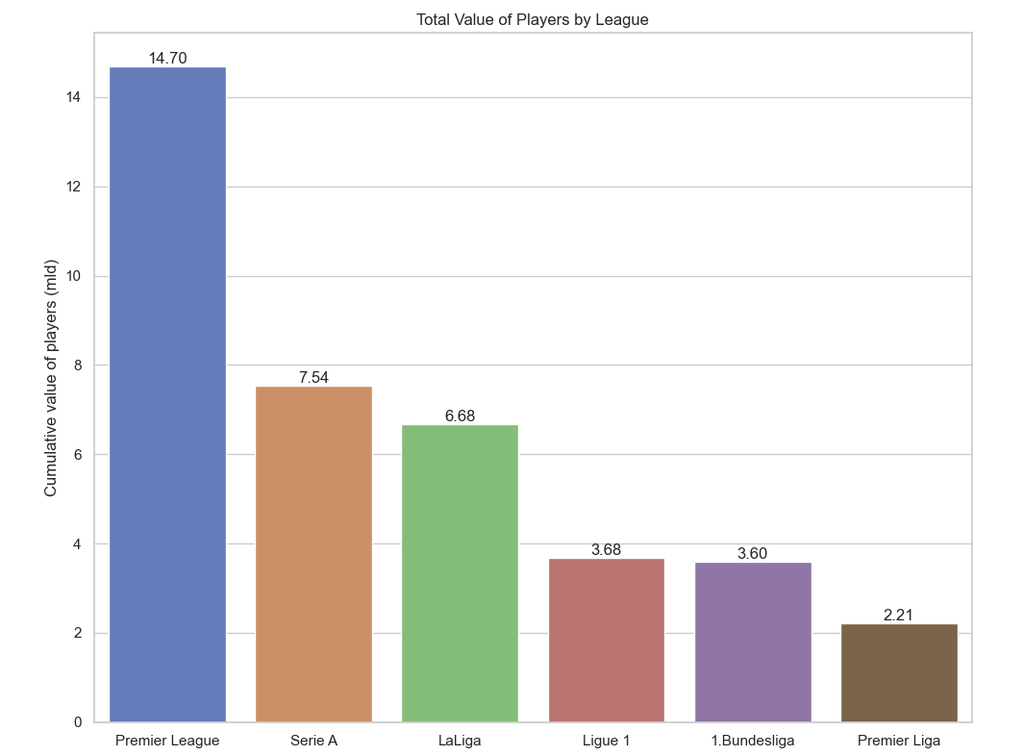

### Which team purchased the most players or spent the most

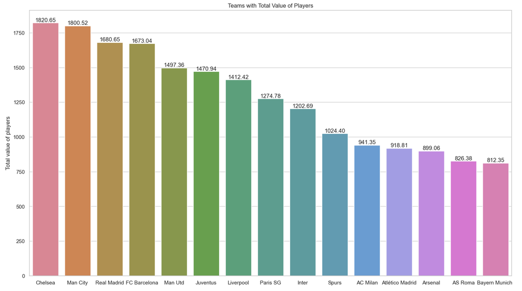